# Sta112FS 12. Simulation based inference

Dr. Çetinkaya-Rundel

October 15, 2015

# Today’s agenda

## Today’s agenda

- New teams! (I’ll need team names ASAP)
- Introduction to inference via simulations
- **Due Tuesday:**
  - Read Chapter 2, Sections 2.1 - 2.4 of [Introductory Statistics with Randomization and Simulation](http://openintro.org/isrs)
  - App Ex

# Inference

## Organ donors

People providing an organ for donation sometimes seek the help of a special “medical consultant”. These consultants assist the patient in all aspects of the surgery, with the goal of reducing the possibility of complications during the medical procedure and recovery. Patients might choose a consultant based in part on the historical complication rate of the consultant’s clients.

One consultant tried to attract patients by noting that the average complication rate for liver donor surgeries in the US is about 10%, but her clients have only had 3 complications in the 62 liver donor surgeries she has facilitated. She claims this is strong evidence that her work meaningfully contributes to reducing complications (and therefore she should be hired!).

## Parameter vs. statistic

A **parameter** for a hypothesis test is the “true” value of interest. We typically estimate the parameter using a **sample statistic** as a **point estimate**.

$p$: true rate of complication

$\hat{p}$: rate of complication in the sample = $\frac{3}{62}$ = 0.048

## Correlation vs. causation

Is it possible to assess the consultant’s claim using the data?

No. The claim is that there is a causal connection, but the data are observational. For example, maybe patients who can afford a medical consultant can afford better medical care, which can also lead to a lower complication rate.

While it is not possible to assess the causal claim, it is still possible to test for an association using these data. For this question we ask, could the low complication rate of $\hat{p}$ = 0.048 be due to chance?

## Two claims

- **Null hypothesis:** “There is nothing going on”

Complication rate for this consultant is no different than the US average of 10%

- **Alternative hypothesis:** “There is something going on”

Complication rate for this consultant is **lower** than the US average of 10%

## Hypothesis testing as a court trial

- **Null hypothesis**, $H_0$: Defendant is innocent
- **Alternative hypothesis**, $H_A$: Defendant is guilty
- **Present the evidence:** Collect data
- **Judge the evidence:** “Could these data plausibly have happened by chance if the null hypothesis were true?”
  - Yes: Fail to reject $H_0$
  - No: Reject $H_0$

## Hypothesis testing framework

- Start with a null hypothesis ($H_0$) that represents the status quo
- Set an alternative hypothesis ($H_A$) that represents the research question, i.e. what we’re testing for
- Conduct a hypothesis test under the assumption that the null hypothesis is true and calculate a **p-value** (probability of observed or more extreme outcome given that the null hypothesis is true)
  - if the test results suggest that the data do not provide convincing evidence for the alternative hypothesis, stick with the null hypothesis
  - if they do, then reject the null hypothesis in favor of the alternative

## Setting the hypotheses

Which of the following is the correct set of hypotheses?

1. $H_0: p = 0.10$; $H_A: p \ne 0.10$
2. $H_0: p = 0.10$; $H_A: p > 0.10$
3. $H_0: p = 0.10$; $H_A: p < 0.10$
4. $H_0: \hat{p} = 0.10$; $H_A: \hat{p} \ne 0.10$
5. $H_0: \hat{p} = 0.10$; $H_A: \hat{p} > 0.10$
6. $H_0: \hat{p} = 0.10$; $H_A: \hat{p} < 0.10$

## Simulating the null distribution

- Since $H_0: p = 0.10$, we need to simulate a null distribution where the probability of success (complication) for each trial (patient) is 0.10.

Describe how you would simulate the null distribution for this study using a bag of chips. How many chips? What colors? What do the colors indicate? How many draws? **With replacement** or **without replacement**?

## What do we expect?

When sampling from the null distribution, what is the expected proportion of success (complications)?

## Set-up

```r
set.seed(9)
library(ggplot2)
```

## Simulation #1

```r
# create sample space
outcomes <- c("complication", "no complication")

# draw the first sample of size 62 from the null distribution
sim1 <- sample(outcomes, size = 62, prob = c(0.1, 0.9), replace = TRUE)

# view the sample
table(sim1)
```

```
## sim1
##    complication no complication
##              11              51
```

```r
# calculate the simulated sample proportion of complications (red chips)
(p_hat_sim1 <- sum(sim1 == "complication") / length(sim1))
```

```
## [1] 0.1774194
```

## Recording and plotting

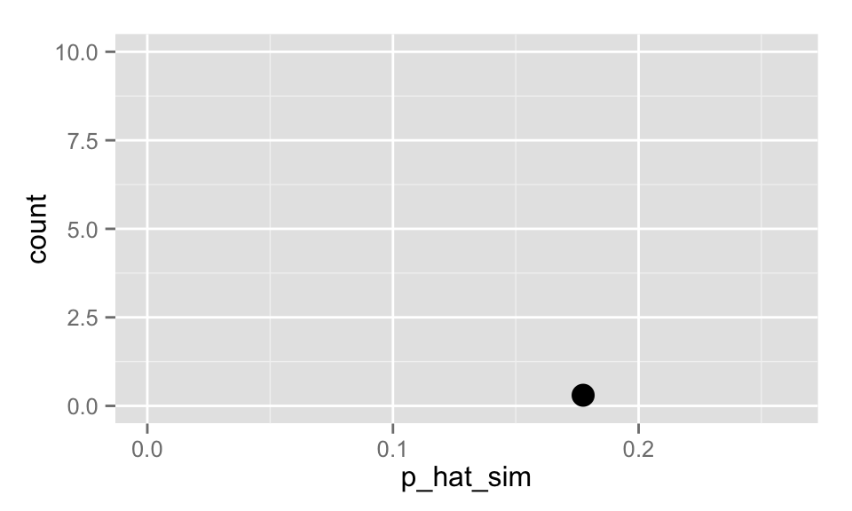

```r
# create an empty data frame
sim_dist <- data.frame(p_hat_sim = rep(NA, 100))

# record the simulated p-hat as the first observation
sim_dist$p_hat_sim[1] <- p_hat_sim1

# plot
ggplot(sim_dist, aes(x = p_hat_sim)) +
  geom_dotplot() +
  xlim(0, 0.26) + ylim(0, 10)
```

## Simulation #2

```r
sim2 <- sample(outcomes, size = 62, prob = c(0.1, 0.9), replace = TRUE)

(p_hat_sim2 <- sum(sim2 == "complication") / length(sim2))
```

```
## [1] 0.08064516
```

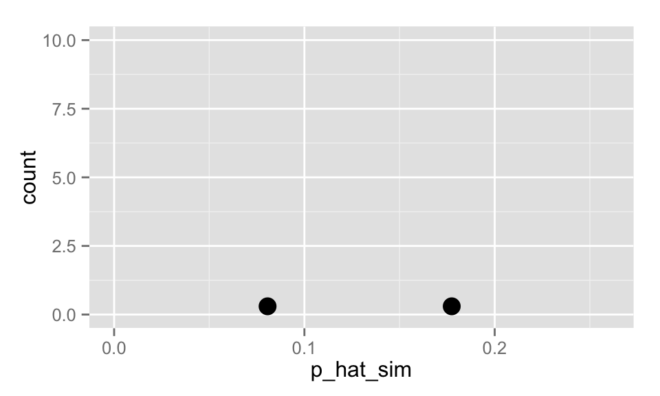

```r
sim_dist$p_hat_sim[2] <- p_hat_sim2

ggplot(sim_dist, aes(x = p_hat_sim)) +
  geom_dotplot() +
  xlim(0,0.26) + ylim(0,10)
```

## Simulation #3

```r
sim3 <- sample(outcomes, size = 62, prob = c(0.1, 0.9), replace = TRUE)

(p_hat_sim3 <- sum(sim3 == "complication") / length(sim3))
```

```
## [1] 0.2096774
```

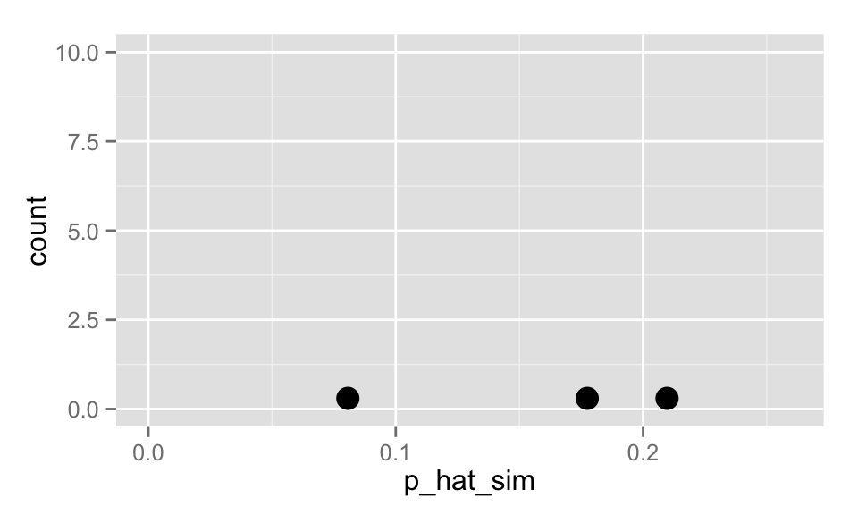

```r
sim_dist$p_hat_sim[3] <- p_hat_sim3

ggplot(sim_dist, aes(x = p_hat_sim)) +
  geom_dotplot() +
  xlim(0,0.26) + ylim(0,10)
```

## This is getting boring…

We need a way to automate this process!

# Simple Looping

## `for` loops

Simplest, and most common type of loop in R - iterate through the elements of a vector and evaluate the code block for each.

```r
for(x in 1:10)
{
  cat(x^2," ", sep="") # cat: concatenate and print
}
```

```
## 1 4 9 16 25 36 49 64 81 100
```

```r
for(y in list(1:3, LETTERS[1:7], c(TRUE,FALSE)))
{
  cat(length(y)," ",sep="")
}
```

```
## 3 7 2
```

## Storing results

Almost always it is better to create an object to store your results first, rather than growing the object as you go.

```r
# Good
res <- rep(NA,10)
for(x in 1:10)
{
  res[x] <- x^2
}
res
```

```
##  [1]   1   4   9  16  25  36  49  64  81 100
```

```r
# Bad
res <- c()
for (x in 1:10)
{
  res <- c(res,x^2)
}
res
```

```
##  [1]   1   4   9  16  25  36  49  64  81 100
```

# Back to inference

## Using loops to create the null distribution

- Earlier we simulated each iteration one-by-one and showed how we would fill in each element of `sim_dist$p_hat_sim`.
- Using for loops we can automate this process

## Simulating the null distribution with a `for` loop

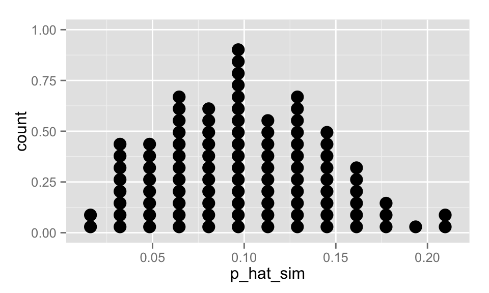

```r
sim_dist <- data.frame(p_hat_sim = rep(NA, 100))
for (i in 1:100){
  sim <- sample(outcomes, size = 62, prob = c(0.1, 0.9), replace = TRUE)
  p_hat_sim <- sum(sim == "complication") / length(sim)
  sim_dist$p_hat_sim[i] <- p_hat_sim
}

ggplot(sim_dist, aes(x = p_hat_sim)) +
  geom_dotplot()
```

## Calculating the p-value

Remember **p-value** is probability of observed or more extreme outcome given that the null hypothesis is true.

What is the p-value, i.e. in what % of the simulations was the simulated $\hat{p}$ was at least as extreme as the observed $\hat{p}$ of 0.048?

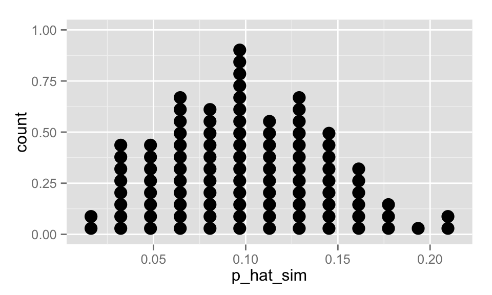

## Significance level

We often use 5% as the cutoff for whether the p-value is low enough that the data are unlikely to have come from the null model. This cutoff value is called the **significance level** ($\alpha$).

- If p-value < $\alpha$, reject $H_0$ in favor of $H_A$: The data provide convincing evidence for the alternative hypothesis.
- If p-value > $\alpha$, fail to reject $H_0$ in favor of $H_A$: The data do not provide convincing evidence for the alternative hypothesis.

## Conclusion

What is the conclusion of the hypothesis test?

Since the p-value is greater than the significance level, we fail to reject the null hypothesis. These data do not provide convincing evidence that this consultant incurs a lower complication rate than 10% (overall US complication rate).

## Let’s get real

- 100 simulations is not sufficient
- We usually simulate around 15,000 times to get an accurate distribution

# Application Exercise

## App Ex 6 - Inference for a proportion

in your new teams!

See course website for details.